# Rによる機械学習 k近傍法

Cho（ztempest0218@gmail.com）

Last Updated: 2026-10-12

**データのダウンロード**

Kaggleの内向型・外向型データを使う。保存先は、講義のプロジェクトフォルダを基準にする。

- **演習データ**：train.csv ／ test.csvを `data/personality/` に保存する。

**今回の内容**

- k近傍法（k-NN）の考え方
- 距離・標準化・ダミー変数化
- 交差検証によるkの選択
- Rによる内向型・外向型の分類と評価

# 1 統計モデルの分類

統計モデルは、関数形式をどこまで事前に仮定するかによって、大きくパラメトリック、セミパラメトリック、ノンパラメトリックの3つに整理できる。

| 分類 | 先に決めるもの | 具体例 |
| --- | --- | --- |
| パラメトリック （parametric） | 関数形式と係数の個数を決める | $f(x)=\beta_0+\beta_1x$ |
| セミパラメトリック （semiparametric） | 一部だけ関数形式を決める | $f(x,z)=\beta x+g(z)$ |
| ノンパラメトリック （nonparametric） | 特定の関数形式には限定しない | k-NN回帰で近い3件を使う場合： $\hat y=(y_1+y_2+y_3)/3$ |

上の表は直感的な理解のための整理であり、厳密な数学的定義ではない。詳しく学びたい人は、確率論や数理統計学の教科書を各自で参照してほしい。

**パラメトリック（parametric）**な回帰の例として、重回帰では次の式を使う。

$$y_i=\beta_0+\beta_1x_{i1}+\cdots+\beta_px_{ip}+\varepsilon_i$$

$y_i$ は予測したい値、$x_{i1},\ldots,x_{ip}$ は説明変数、$\beta_0,\ldots,\beta_p$ はデータから求める係数、$\varepsilon_i$ は式では説明しきれない部分である。使う説明変数を変えなければ、データが100件から1000件に増えても、**求める係数は $p+1$ 個のままである**。

ここで先に固定するのは、$f$ の具体的な値ではなく、関数形式である。たとえば、直線を使うか、二次曲線を使うかを分析者が決める。

$$\begin{aligned}
\text{Linear:}\quad f(x)&=\beta_0+\beta_1x \\
\text{Quadratic:}\quad f(x)&=\beta_0+\beta_1x+\beta_2x^2
\end{aligned}$$

パラメトリックなモデルは、関数形式を適切に設定できれば、少ないデータでも高い予測精度を得られることがある。一方、関数形式の設定を誤ると、予測が実際の値から大きく外れる可能性がある。

**セミパラメトリック（semiparametric）**は、関数形式をあらかじめ決める部分と、特定の関数形式に限定せずデータから学ぶ部分を組み合わせる考え方である。表の例では、$x$ との関係は直線と決め、$z$ との関係は $g(z)$ で柔軟に表す。これは回帰の一例であり、この考え方は回帰以外にも使われる。

**ノンパラメトリック（nonparametric）**は、関数形式を直線や二次曲線などにあらかじめ限定せず、データから関係を学ぶ方法である。パラメトリックでは、先に決めた関数形式の係数を求める。ノンパラメトリックでは、データ全体の関係を決まった個数の係数だけにまとめず、データに応じて関係を捉える。ただし、学習のルールや調整する設定は必要である。

利点は、**関数形式の制約が少なく、線形関係に限らず複雑な関係にも柔軟に対応できる**ことである。一方、複雑な関係を学ぶには十分なデータが必要で、データが少ない領域では予測が不安定になりやすい。また、関係を一つの共通の係数で説明しにくい。ただし、k-NNに変えても、多重共線性や高次元性の問題が自動的に解決するわけではない。

これまで学んだ線形回帰・Ridge・Lassoは、いずれも関数形式をあらかじめ設定するパラメトリックな手法である。Lassoは一部の係数を0にできるが、候補となる変数や二乗項・交差項などは分析者が先に用意する。今回は、これらとノンパラメトリックなk近傍法の違いを考える。

# 2 k近傍法（k-NN）

NNはnearest neighbor（最近傍）の略である。ここでいう最近傍は、予測したい対象と、特徴量 $X$（説明変数）の値が最も近いデータを指す。k-NN（k-nearest neighbors）は、この $X$ の距離が近い順にk件の学習データを選び、対応する目的変数 $y$ を使って予測する方法である。

k近傍法の考え方は、「特徴が似ているデータを参考にする」ことである。機械学習のアルゴリズムの中でも、最も直感的で理解しやすいものの一つかもしれない。機械学習の教科書では分類器として紹介されることが多いが、住宅価格のような数値を予測する回帰にも使える。まずは、多数決を使う分類から考えよう。

## 2.1 特徴が似たデータから分類する

りんご

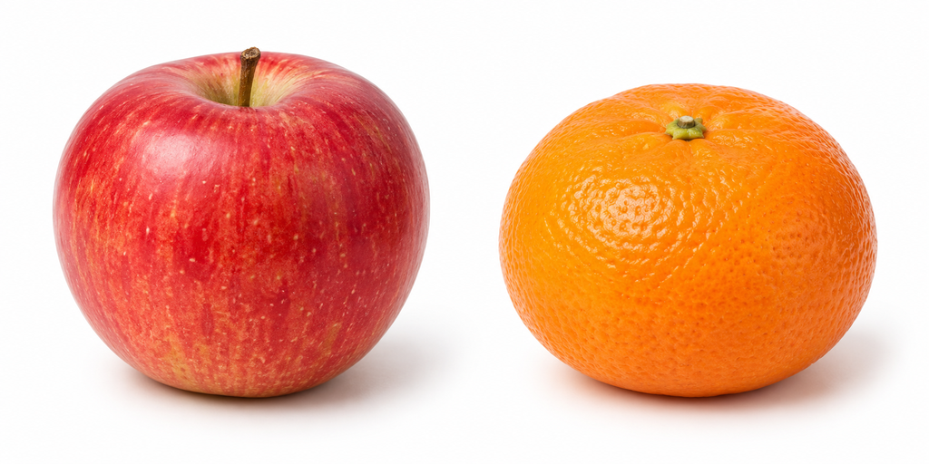

みかん

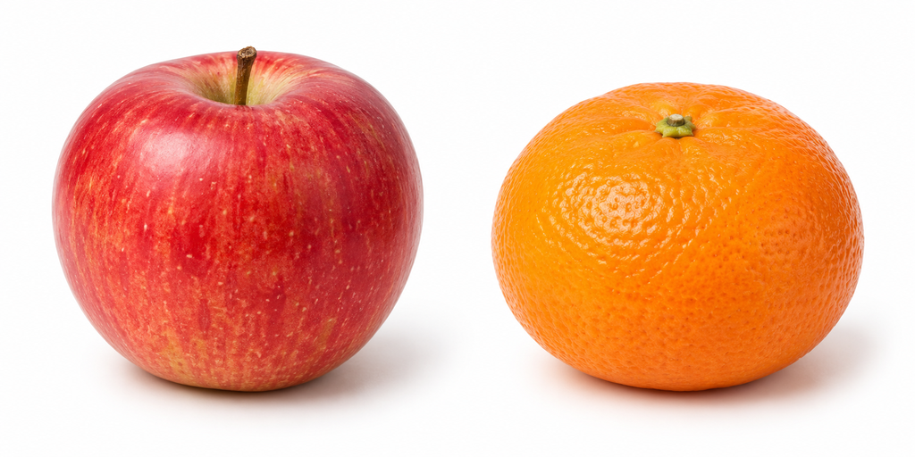

ある果物が「りんご」と「みかん」のどちらかを、重さと直径から予測するとしよう。特徴量 $X$ は重さと直径、目的変数 $y$ は果物の種類である。

予測したい果物は、重さ150g、直径7.0cmとする。以下は、種類がわかっている9個の果物の架空データである。

| データ | 重さ（g） | 直径（cm） | 種類 |
| --- | --- | --- | --- |
| A | 145 | 6.6 | りんご |
| B | 175 | 7.4 | りんご |
| C | 100 | 6.0 | みかん |
| D | 215 | 8.0 | りんご |
| E | 80 | 5.6 | みかん |
| F | 240 | 8.4 | りんご |
| G | 60 | 5.1 | みかん |
| H | 270 | 8.8 | りんご |
| I | 50 | 4.7 | みかん |

この9個から距離が小さい順に3個を選ぶと、A・B・Cになる。りんごが2個、みかんが1個なので、多数決で新しい果物を「りんご」と予測する。特徴量 $X$ が近いデータを選び、その種類 $y$ の多数決をとるのがポイントである。このように、どのカテゴリに当てはまるかを予測することを分類という。

ここでは近い3個を参考にしたので、$k=3$ である。kは、予測に使う近傍の数を表す。距離の計算や、重さと直径の単位の違いを調整する方法は、次の節で説明する。

## 2.2 類似度を距離で計測する

最近傍を見つけるには、データ同士の類似度を数値で表す距離関数を使う。この距離が小さいほど特徴量 $X$ の値が似ているとみなし、予測対象との距離が最も小さいデータを最近傍とする。代表的な距離にはユークリッド距離やマンハッタン距離がある。本講義では、直線の長さとして理解しやすいユークリッド距離を中心に扱う。

### 2.2.1 ユークリッド距離

ユークリッド距離（Euclidean distance）は、2点を直線で結んだときの線分の長さである。下図では、わかりやすくするため、直径と重さの2つの特徴量 $X=(x_1,x_2)$ を使い、各データを二次元平面上の点として表している。右図の円は、選ばれた近傍の集合を示すものである。

2つの観測を $\vec{x}_a=(x_{a1},x_{a2})$、$\vec{x}_b=(x_{b1},x_{b2})$ とする。横座標の差の大きさは $|x_{a1}-x_{b1}|$、縦座標の差の大きさは $|x_{a2}-x_{b2}|$ なので、三平方の定理から距離は次のように求められる。

$$d(\vec{x}_a,\vec{x}_b)=\sqrt{(x_{a1}-x_{b1})^2+(x_{a2}-x_{b2})^2}$$

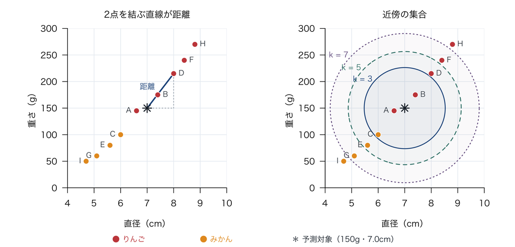

＊（150g・7.0cm）との距離を計算する。

| データ | 種類 | 重さ（g） | 直径（cm） | 距離の計算 | 距離 |
| --- | --- | --- | --- | --- | --- |
| A | りんご | 145 | 6.6 | $\sqrt{(6.6-7.0)^2+(145-150)^2}$ | 5.016 |
| B | りんご | 175 | 7.4 | $\sqrt{(7.4-7.0)^2+(175-150)^2}$ | 25.003 |
| C | みかん | 100 | 6.0 | $\sqrt{(6.0-7.0)^2+(100-150)^2}$ | 50.010 |

$k=3$ と設定した場合、予測対象との距離が小さい順に3個のデータを選ぶ。この例ではA・B・Cが選ばれ、りんごが2個、みかんが1個なので、多数決で「りんご」と予測する。

2クラスの分類では、同票を避けるために奇数の $k$ を使うことが多い。ただし、3クラス以上では奇数の $k$ でも同票になることがある。

重さや直径以外にも特徴量 $X$ を加えると、データは3次元以上になる。特徴量が $p$ 個の場合も、それぞれの差を二乗して足し合わせ、平方根をとることで距離を計算できる。

$$d(\vec{x}_a,\vec{x}_b)
=\sqrt{\sum_{j=1}^{p}(x_{aj}-x_{bj})^2}$$

## 2.3 特徴量エンジニアリング

Rでは因子型 `factor` が自動で数値化されることもあるが、処理は関数や入力方法によって異なる。特徴量エンジニアリングでは、**自動処理に任せきりにせず、変数の型や変換結果を自分で確認する**ことが大切である。

ダミー変数の基本については、Wooldridge『Introductory Econometrics: A Modern Approach』（第7版）の第7章「Multiple Regression Analysis with Qualitative Information」を参照してほしい。

### 2.3.1 標準化

機械学習では、ユークリッド距離や二乗誤差のように、差を二乗して足し合わせる計算をよく使う。データの情報が同じでも、測定単位を変えるだけで数値の大きさが変わり、説明変数ごとの距離への影響も変わる。そこで、距離計算に使う数値型の特徴量 $X$ の尺度をそろえる。代表的な方法として、次の2つがある。

**z-score標準化**は、前回のRidge・Lasso回帰でも使った方法である。各変数から平均を引き、標準偏差で割る。学習データでは、平均が0、標準偏差が1になる。初級統計で学んだ、正規分布に従う変数から平均を引き、標準偏差で割って標準正規分布に変換する操作と同じ考え方である。

$$z_{ij}=\frac{x_{ij}-\bar{x}_{j,\mathrm{train}}}{s_{j,\mathrm{train}}}$$

**min-max正規化**は、各変数の最小値を0、最大値を1にそろえる方法である。学習データの値は0〜1の範囲になる。

$$x_{\mathrm{new}}=\frac{x_{ij}-x_{j,\min}}{x_{j,\max}-x_{j,\min}}$$

ここで、$x_{\mathrm{new}}$ は変換後の値である。表記を簡潔にするため $\mathrm{train}$ を省略しているが、$x_{j,\min}$ と $x_{j,\max}$ は、どちらも学習データにおける変数 $j$ の最小値・最大値を指す。

どちらも、平均・標準偏差や最小値・最大値は学習データだけから求め、検証用・テスト用データにも同じ値を使う。

前回のRidge・Lasso回帰では、`glmnet()`関数に `standardize = TRUE` と指定すれば、内部で標準化されるため、自分で標準化した変数を用意する必要はなかった。一方、k近傍法（k-NN）のアルゴリズムには、標準化の処理は含まれていない。入力する特徴量の尺度を自分で確認し、必要に応じて事前に標準化する必要がある。

乱数で100個の学習データを作り、同じデータにz-score標準化とmin-max正規化を適用してみよう。`summarise()` で最小値・平均・標準偏差・中央値・最大値を求め、表で比較する。

```r
library(tidyverse)

# 乱数を発生
set.seed(123)
x <- rnorm(100, mean = 50, sd = 10)

# まず手動で計算する
scaled_data <- data.frame(
  original = x,
  z_score = (x - mean(x)) / sd(x),
  min_max = (x - min(x)) / (max(x) - min(x))
)

# z-scoreとmin-maxの記述統計を出す
scaled_data %>%
  pivot_longer(everything()) %>%
  group_by(name) %>%
  summarise(
    min = min(value),
    mean = mean(value),
    sd = sd(value),
    median = median(value),
    max = max(value)
  ) %>%
  arrange(match(name, c("original", "z_score", "min_max"))) %>%
  knitr::kable(digits = 3)
```

| name | min | mean | sd | median | max |
| --- | --- | --- | --- | --- | --- |
| original | 26.908 | 50.904 | 9.128 | 50.618 | 71.873 |
| z_score | -2.629 | 0.000 | 1.000 | -0.031 | 2.297 |
| min_max | 0.000 | 0.534 | 0.203 | 0.527 | 1.000 |

z-score標準化では平均が0、標準偏差が1になる。min-max正規化では最小値が0、最大値が1になるが、平均や標準偏差は決まった値にはならない。min-max正規化は学習データ全体を0〜1に収めるため、外れ値によって最小値や最大値が大きく変わると、多くのデータが狭い範囲に圧縮される。

後の演習では、tidyverseと連携する `recipes` パッケージを使って、z-score標準化を自動で行う。ここで示したように手動で計算する必要はなく、変数が多い場合もまとめて処理できる。興味があれば、z-score標準化とmin-max正規化を使ったモデルの予測性能を、交差検証で比較してみよう。

### 2.3.2 ダミー変数化

k近傍法では特徴量 $X$ を使って距離を計算する。一方、分類の結果変数 $y$ は距離計算に使わず、選ばれた近傍の多数決に使う。$y$ のダミー変数化や標準化は不要であり、ここでは因子型（`factor`）として扱う。

たとえば「りんご」を1、「みかん」を0とし、近傍の $y$ が1、1、0の場合を考えよう。$y$ を数値型として回帰に使うと、予測値は平均の $(1+1+0)/3=0.667$ になる。一方、分類では多数決により「りんご」と予測する。`caret::train()` では数値型の $y$ は回帰、因子型の $y$ は分類として扱われるため、データ型に注意しよう。

カテゴリ変数の $X$ を距離計算に使う場合は、次のようにカテゴリごとのダミー変数に置き換える。ここで、$X$ の1、2、3は、それぞれ「赤」「緑」「オレンジ」を区別する番号であり、順序を表すものではない。

**カテゴリ変数を複数のダミーで表現**

| カテゴリ変数 $X$ | $D_1$ | $D_2$ | $D_3$ |
| --- | --- | --- | --- |
| 1（赤） | 1 | 0 | 0 |
| 2（緑） | 0 | 1 | 0 |
| 3（オレンジ） | 0 | 0 | 1 |

番号をそのまま使うと、1と2の距離は1、1と3の距離は2になる。しかし、カテゴリ間にこのような大小関係や等間隔の尺度があるわけではない。他の特徴量の値が同じであると仮定すると、上の3列を使えば、異なるカテゴリ間のユークリッド距離はすべて $\sqrt{2}$ になる。距離計算では、元の $X$ の代わりに $D_1$、$D_2$、$D_3$ を使う。このように各カテゴリに1列ずつ対応させる方法では、カテゴリの種類と同じ数のダミー変数を作る。

Rでも、色の文字列から3列のダミー変数を作ってみよう。`factor()` でカテゴリの順番を指定する。`model.matrix()` の `- 1` は切片の列を除く指定で、ここでは各色に対応する3列が作られる。

```r
# 色を因子型にする（出現順に1、2、3）
color <- c("red", "green", "orange", "red", "orange")
color <- factor(color, levels = unique(color))

# 各色に対応する3列のダミー変数を作る
dummy_color <- model.matrix(~ color - 1)
```

## 2.4 数値のyも予測できる：住宅価格の例

k近傍法は、カテゴリ変数の $y$ を予測する分類器としてよく紹介されるが、数値の $y$ も予測できる。$y$ がカテゴリなら近傍の多数決を使い、数値なら近傍の平均値を使う。たとえば住宅価格なら、面積や築年数などの特徴が似ている住宅を選び、その価格を平均して予測する。

下図は、居住面積と築年数の2つの特徴量で比較する例である。学習データの平均・標準偏差で両変数を標準化して距離を求め、近い3軒を選ぶ。左図の軸は、読みやすいように元の単位で表示している。

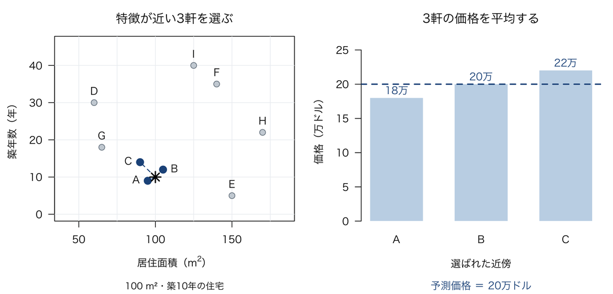

たとえば、条件の近い3軒の価格が18万ドル、20万ドル、22万ドルなら、その平均の20万ドルを予測値にする。一般に、結果変数 $y$ が連続値の場合、予測対象 $\vec{x}_0$ に最も近い $k$ 個の学習データの平均で予測する。その近傍の集合を $N_k(\vec{x}_0)$ と書くと、

$$\hat{y}(\vec{x}_0)=\frac{1}{k}\sum_{i\in N_k(\vec{x}_0)}y_i$$

となる。$y_i$ は選ばれた近傍の結果変数の値である。係数を推定しなくても、既知の住宅と比較することで価格を予測できる。

ここで「近い」とは、住所が近いという意味に限らない。説明変数で表した特徴が近いという意味である。立地を使わず面積と築年だけで比較すると、別の地域の住宅も近傍になりうる。どの特徴量を使うかによって、似ているという判断そのものが変わる。

## 2.5 k近傍法の手順

k近傍法（k-NN）は、線形回帰のように予測式の関数形式をあらかじめ決めず、予測対象と特徴量が最も近い $k$ 個の学習データを直接参考にする。そのため、$k$ の選び方も予測性能に影響する。基本的な手順は次のとおりである。

（0 最小限必要なデータクリーニング）

1. データを学習用・検証用・テスト用に分ける。
2. 学習データで前処理の基準を求め、検証・テストデータにも同じ基準を適用する。
3. 予測対象と学習データの距離を計算する。
4. 学習データから、予測対象に最も近い $k$ 個を選ぶ。
5. 近傍の $y$ の多数決（分類）または平均（回帰）で予測する。

**補完値や標準化の平均・標準偏差は、必ずデータを分割した後、学習データだけから求める。**分割前に全データから求めると、検証・テストデータの情報が入り、情報漏洩が起こる。交差検証でも、各foldの学習部分だけで前処理の基準を求める。（ただし、明らかな表記ミスの修正や変数の型の変換など、標本から求める統計量に依存しない処理は、データの分割前に行ってよい。）

### 2.5.1 kの選択と評価

kはハイパーパラメータである。経験則として、学習データの件数を $n$ として $k\approx\sqrt{n}$ を目安に決める方法もある。ただし、この目安が最適とは限らないため、本講義では前回のRidge・Lasso回帰における $\lambda$ と同じく、**交差検証**で未知データへの予測性能を評価して決める。

| k | 予測の特徴 | 起こりうる問題 |
| --- | --- | --- |
| 小さい | ごく近くの観測だけに反応する | ノイズに敏感で、過学習しやすい |
| 大きい | 広い範囲をまとめて平均・投票する | 局所的な違いを失い、欠学習しやすい |

りんご／みかんのデータと予測対象で、近傍の数だけを変えてみよう。黒い＊が予測対象、円内の点が投票に使う近傍である。2つの特徴量は同じ尺度にそろえている。

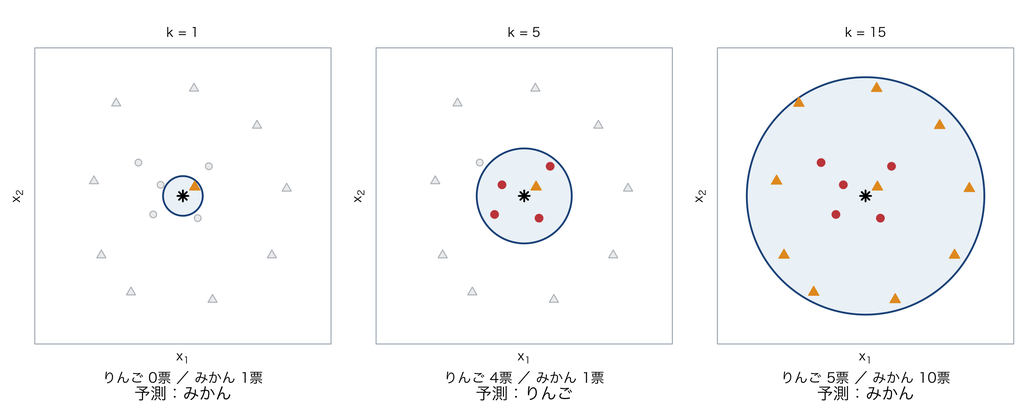

$k=1$ では近い1個の影響が大きく、$k=15$ では離れた果物の票も予測を左右する。$k$ を変えると、参考にする範囲も予測結果も変わる。

### 2.5.2 特徴量と計算上の注意点

k近傍法の予測は、特徴量から計算する距離に左右される。そのため、2.3節で学んだ特徴量エンジニアリングが重要になる。標準化やダミー変数化に加え、使う特徴量も確認する必要がある。

情報の重複を**特徴量の冗長性（Redundancy）**という。多重共線性が線形関係を指すのに対し、冗長性には非線形の重複も含まれる。たとえば「重量（g）」と「重量（kg）」を両方使うと、標準化しても重量の情報を距離に2回分数えることになる。線形回帰からk近傍法に変えても、こうしたデータの問題は消えない。

また、特徴量が多すぎると、同じデータ数でも近い観測を見つけにくくなる（次元の呪い）。不要な特徴量を減らすことも大切である。予測時には学習データを参照するため、データが大きいと計算時間や保存容量も必要になる。

# 3 Rによる内向型・外向型の分類

Kaggleの [Predict the Introverts from the Extroverts](https://www.kaggle.com/competitions/playground-series-s5e7/data) を使い、生活や社交に関する7個の特徴量から、内向型（Introvert）か外向型（Extrovert）かを予測する。学習用データは18,524件、正解が公開されていない予測用データは6,175件である。このデータは元の行動データから生成された合成データであり、演習用として扱う。

データは [Kaggleのコンペティションデータの公開ミラー](https://github.com/Gaby-gif/S5E7---Predict-the-Introverts-from-the-Extroverts/tree/main/input) から取得した。train.csv と test.csv を講義のプロジェクト内に保存している。

まず、「一人で過ごす時間」と「親しい友人の人数」の2つだけで考えてみよう。下図の点は実データから抜き出した120人、黒い＊は予測したい人物の例である。2変数を標準化して距離を求め、近い5人の多数決で予測する。線で結んだ5人が、その予測に使う近傍である。

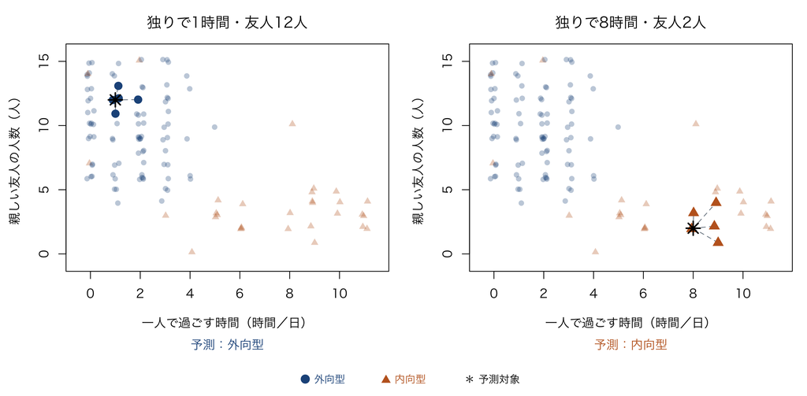

## 3.1 データと前処理

このデータは、1つの結果変数y（内向型／外向型）と7つの特徴量Xからなる、比較的シンプルな構成である。

| 列名 | 内容 | 単位 | 型 | todo |
| --- | --- | --- | --- | --- |
| Time_spent_Alone | 1日の独りで過ごす時間 | 時間 | 数値 | 標準化 |
| Stage_fear | 人前で話すことへの恐れ | ― | Yes / No | ダミー変数化 |
| Social_event_attendance | 社交イベントへの参加頻度 | 不明 | 数値 | 標準化 |
| Going_outside | 外出の頻度 | 不明 | 数値 | 標準化 |
| Drained_after_socializing | 交流後に疲れを感じるか | ― | Yes / No | ダミー変数化 |
| Friends_circle_size | 親しい友人の人数 | 人 | 数値 | 標準化 |
| Post_frequency | SNSへの投稿頻度 | 不明 | 数値 | 標準化 |
| Personality | 内向型／外向型 | ― | カテゴリ | 因子型factorにする |

`Social_event_attendance` と `Post_frequency` は0～10、`Going_outside` は0～7の値をとり、数値が大きいほど頻度が高いことを表す。ただし、各数値の具体的な定義は示されておらず、1から2への増加と、2から3への増加が、実際の行動頻度の同じ幅の増加を意味するとは限らない。本演習では、計算上は等間隔の数値として扱う。

```r
library(tidyverse)
library(recipes)
library(caret)

# 適宜wdを設定すること

personality <- read.csv("data/personality/train.csv", na.strings = "")
kaggle_test <- read.csv("data/personality/test.csv", na.strings = "")
head(personality)
```

|  | id | Time_spent_Alone | Stage_fear | Social_event_attendance | Going_outside | Drained_after_socializing | Friends_circle_size | Post_frequency | Personality |
| --- | --- | --- | --- | --- | --- | --- | --- | --- | --- |
| 1 | 0 | 0 | No | 6 | 4 | No | 15 | 5 | Extrovert |
| 2 | 1 | 1 | No | 7 | 3 | No | 10 | 8 | Extrovert |
| 3 | 2 | 6 | Yes | 1 | 0 | NA | 3 | 0 | Introvert |
| 4 | 3 | 3 | No | 7 | 3 | No | 11 | 5 | Extrovert |
| 5 | 4 | 1 | No | 4 | 4 | No | 13 | NA | Extrovert |
| 6 | 5 | 2 | No | 8 | 5 | No | NA | 3 | Extrovert |

```r
str(personality)
```

```
## 'data.frame':    18524 obs. of  9 variables:
##  $ id                       : int  0 1 2 3 4 5 6 7 8 9 ...
##  $ Time_spent_Alone         : num  0 1 6 3 1 2 1 2 4 1 ...
##  $ Stage_fear               : chr  "No" "No" "Yes" "No" ...
##  $ Social_event_attendance  : num  6 7 1 7 4 8 8 8 2 8 ...
##  $ Going_outside            : num  4 3 0 3 4 5 NA 3 1 6 ...
##  $ Drained_after_socializing: chr  "No" "No" NA "No" ...
##  $ Friends_circle_size      : num  15 10 3 11 13 NA NA 4 0 14 ...
##  $ Post_frequency           : num  5 8 0 5 NA 3 4 5 2 9 ...
##  $ Personality              : chr  "Extrovert" "Extrovert" "Introvert" "Extrovert" ...
```

```r
colSums(is.na(personality))
```

```
##                        id          Time_spent_Alone                Stage_fear
##                         0                      1190                      1893
##   Social_event_attendance             Going_outside Drained_after_socializing
##                      1180                      1466                      1149
##       Friends_circle_size            Post_frequency               Personality
##                      1054                      1264                         0
```

`str()` で `chr` と表示される列は文字列であり、そのままではk近傍法の距離計算に使えない。すべての `chr` 列について、内容や表記の揺れ、欠損値を自分で確認し、用途に応じて因子型への変換やダミー変数化などの前処理を行おう。ここでは、結果変数 `Personality` を因子型に変換し、特徴量のYes / Noは後の `recipes` でダミー変数化する。

```r
# 分類の結果変数を文字列から因子型に変換する
personality$Personality <- factor(personality$Personality)
class(personality$Personality)
```

```
## [1] "factor"
```

## 3.2 recipeによる一括データ処理

前処理は、変数ごとにコードを書くか、`for` 文で繰り返して行うこともできる。ただし、変数が多くなると、処理の書き分けや確認に手間がかかる。そこで、ここでは `recipes` パッケージを使い、変数の型に応じた前処理をまとめて定義する。

`recipes` では、**欠損値の補完、標準化、ダミー変数化**、変動しない変数の削除などを、`step_` で始まる関数で順に指定できる。数値の特徴量だけ、カテゴリの特徴量だけをまとめて選べるため、列名を一つずつ指定する必要がない。**学習データで求めた処理の基準は、検証・テストデータにも適用できる。**

よく使う `step_` 関数には、次のものがある。括弧内には処理したい変数を指定する。

| 関数 | 処理 |
| --- | --- |
| `step_impute_median()` | 欠損値を中央値で補完 |
| `step_impute_mode()` | 欠損値を最頻値で補完 |
| `step_normalize()` | 平均0・標準偏差1に標準化 |
| `step_range()` | 通常、最小値0・最大値1に変換 |
| `step_dummy()` | カテゴリ変数をダミー変数化 |
| `step_zv()` | 変動しない変数を除く |

変数は名前を直接書くほか、以下のようにまとめて指定できる。

| 括弧内の指定 | 対象 |
| --- | --- |
| `変数名` | 指定した1列 |
| `変数名1, 変数名2` | 指定した複数の列 |
| `all_numeric_predictors()` | 数値型の特徴量すべて |
| `all_nominal_predictors()` | カテゴリ型・文字列型の特徴量すべて |
| `all_predictors()` | 特徴量すべて |

たとえば `step_normalize(all_numeric_predictors())` は、数値型の特徴量をまとめて標準化する。`all_predictors()` などの指定には、結果変数yは含まれない。

機械学習では、データを学習用・検証用などに分けて使う。分割前に全データで補完値や標準化の平均・標準偏差を求めると、情報漏洩が起こる。そのため、交差検証では分割するたびに学習部分で前処理の基準を求め直す必要がある。異なるサンプルにも同じ手順を繰り返し適用できるよう、処理をまとめて定義しておくと便利である。

`id` は識別番号、`Personality` は結果変数yなので、距離計算から除く。

```r
# yを指定し、idを除く
rec <- recipe(Personality ~ ., data = select(personality, -id)) %>%
  # 数値の欠損値：中央値で補完
  step_impute_median(all_numeric_predictors()) %>%
  # カテゴリの欠損値：最頻値で補完
  step_impute_mode(all_nominal_predictors()) %>%
  # 数値：z-score標準化
  step_normalize(all_numeric_predictors()) %>%
  # カテゴリ：ダミー変数化
  step_dummy(all_nominal_predictors(), one_hot = TRUE) %>%
  # 変動しない変数を除く
  step_zv(all_predictors())
```

**ここでは前処理の手順だけを定義し、まだ補完や標準化は実行しない。**中央値・最頻値・平均・標準偏差は、データを分割した後、交差検証の各学習部分から求める。評価用データを含めて先に計算すると、情報漏洩が起こる。なお、標準化をダミー変数化より先に指定しているため、生成した0と1には標準化を適用しない。

学習データだけから計算

学習データ

$$\text{平均：}\bar{x}_{\mathrm{train}}
\qquad
\text{標準偏差：}s_{\mathrm{train}}$$

特徴量ごとに求めて保存する

同じ統計量でz-scoreを計算

検証データ

$$z_i^{\mathrm{valid}}=
\frac{x_i^{\mathrm{valid}}-\bar{x}_{\mathrm{train}}}
{s_{\mathrm{train}}}$$

テストデータ

$$z_i^{\mathrm{test}}=
\frac{x_i^{\mathrm{test}}-\bar{x}_{\mathrm{train}}}
{s_{\mathrm{train}}}$$

recipeは便利だが、内部の処理が見えにくいため、その仕組みを理解しておくことが重要である。自分でほかの関数を使って標準化する場合も、学習データから各変数の平均・標準偏差を求め、オブジェクトとして保存し、検証・テストデータにも同じ値を使う。交差検証では、各foldの学習部分から求める。**検証・テストデータをそれぞれ自身の平均・標準偏差でz-scoreに変換してしまうのは、よくある誤りである。**

## 3.3 交差検証用のデータとfoldを準備する

kは分析者が設定するハイパーパラメータであり、不適切な値を選ぶと予測性能が大きく低下することがある。そこで、前回の4.2節「交差検証用のデータとfoldを準備する」と同じ5分割交差検証でkを選ぶ。`train.csv` を5つに分け、4つで学習、残り1つで検証する操作を繰り返す。Kaggleの `test.csv` はkの選択には使わない。

```r
# trainは、foldに分割する前のtrain.csv全体を表す
train <- personality

# 5分割の交差検証サンプルを用意する
set.seed(2026)
folds <- createFolds(train$Personality, k = 5, returnTrain = TRUE)
control <- trainControl(
  method = "cv", number = 5, index = folds,
  savePredictions = "all", selectionFunction = "best"
)
```

前回のRidge・Lasso回帰と、交差検証のコードはほぼ同じである。考え方はシンプルで、5つに分けたデータの学習・検証の役割を入れ替え、5回の結果を平均する。一度だけの分割に比べ、たまたま選んだサンプルによって評価が左右されにくくなる。

`returnTrain = TRUE` は各回で学習に使う行を指定し、`savePredictions = "all"` はすべてのkの検証時の予測を保存する。`selectionFunction = "best"` は平均正解率が最も高いkを選ぶ。補完値や標準化の基準は、各回の学習部分だけから求める。

## 3.4 交差検証でkを選ぶ

`caret` パッケージの `train()` 関数に**前処理の手順 `rec`** と5分割の設定 `control` を渡し、検証用正解率が最も高いkを選ぶ。最頻値だけで予測する `majority_fit` と、特徴量を使う `knn_fit` を、同じfoldで比較する。`method = "null"` は各回の学習部分の最頻値を全員に予測する基準モデルである。

ここでは、$k$ の候補を5、15、31、61、121とする。これらは決まった正解ではなく、少数の近傍から広い範囲の近傍まで、計算量を抑えて比較するための候補である。二値分類の同票を避けやすいように、奇数を選んでいる。

経験則の $k\approx\sqrt{n}$ も目安になる。今回の5分割交差検証では、各回の学習データは約14,819件なので、$\sqrt{14819}\approx122$ となり、121はその近くの候補である。ただし、この経験則が最適とは限らない。まずこの5候補を比較し、必要ならパフォーマンスのよい範囲で候補を細かく設定する。

なお、kの候補を自動で生成して比較する方法もある。候補を増やすほど計算時間も増えるため、興味があれば試してみよう。

`method = "knn"` でk近傍法を指定し、`tuneGrid` で比較するkの候補を指定する。`Accuracy` は5回の正解率の平均、`AccuracySD` はその標準偏差である。選ばれたkを使い、学習用データ全体で前処理とモデルが作られる。

今回は結果変数yが内向型・外向型のカテゴリなので、予測したクラスが正解と一致した割合である**正解率（accuracy）**を使う。前回の住宅価格のように数値を予測する回帰では、予測値と実際の値の差を使った平均二乗誤差（MSE）などで評価できる。なお、分類でも予測確率を評価する場合には、二乗誤差を使う方法がある。

```r
# 最頻値を全員に予測する基準モデル
majority_fit <- train(
  rec,
  data = train,
  method = "null",     # 学習部分の最頻値を使う
  trControl = control, # k-NNと同じfold
  metric = "Accuracy"
)

# 特徴量が近い人から予測するk-NNモデル
k_grid <- data.frame(k = c(5, 15, 31, 61, 121))

set.seed(123)
knn_fit <- train(
  rec,                 # 前処理の手順
  data = train,        # 学習データ
  method = "knn",      # k近傍法
  tuneGrid = k_grid,   # 比較するkの候補
  trControl = control, # 交差検証の設定
  metric = "Accuracy"  # 正解率でkを選ぶ
)

# 最頻値と各kの結果を同じ表で比較する
bind_rows(
  majority_fit$results %>% mutate(model = "Majority", k = "-"),
  knn_fit$results %>% mutate(model = "k-NN", k = as.character(k))
) %>%
  select(model, k, Accuracy, AccuracySD) %>%
  knitr::kable()
```

| model | k | Accuracy | AccuracySD |
| --- | --- | --- | --- |
| Majority | - | 0.7395271 | 0.0000314 |
| k-NN | 5 | 0.9681493 | 0.0017528 |
| k-NN | 15 | 0.9685811 | 0.0019926 |
| k-NN | 31 | 0.9687431 | 0.0019065 |
| k-NN | 61 | 0.9686891 | 0.0018833 |
| k-NN | 121 | 0.9687431 | 0.0018873 |

```r
knn_fit$bestTune
```

|  | k |
| --- | --- |
| 3 | 31 |

次に、kを変えるとモデルの予測性能がどう変わるか、図で確認しよう。横軸はk、縦軸は交差検証の平均正解率であり、高いほど予測がよい。赤い破線は、交差検証で選ばれたkを示す。

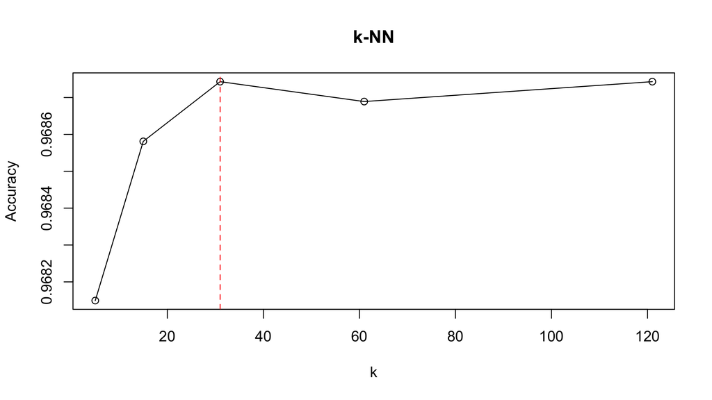

```r
plot(Accuracy ~ k, data = knn_fit$results, type = "o", main = "k-NN")
abline(v = knn_fit$bestTune$k, lty = 2, col = "red")
```

## 3.5 交差検証の予測結果を確かめる

選ばれたk = 31の交差検証での平均正解率は約96.87%である。これまでは、交差検証における全体の平均正解率を基準にkを選んだ。一方、どのような場合に予測を誤るかを調べることも、モデルの改善に役立つ。ここでは、`knn_fit$pred` から予測を取り出し、実際のクラスと予測したクラスを組み合わせた2×2の表（混同行列）で確認しよう。行は実際のクラス、列は予測したクラスを表す。

```r
cv_pred <- subset(knn_fit$pred, k == knn_fit$bestTune$k)
confusion <- table(Actual = cv_pred$obs, Predicted = cv_pred$pred)
confusion
```

```
##            Predicted
## Actual      Extrovert Introvert
##   Extrovert     13434       265
##   Introvert       314      4511
```

|  |  | 予測 内向型（Introvert） | 予測 外向型（Extrovert） |
| --- | --- | --- | --- |
| 実際 | 内向型 （Introvert） | 4511人 | 314人 |
|  | 外向型 （Extrovert） | 265人 | 13434人 |

対角線上の数字（4511人・13434人）は、各クラスを正しく予測できた人数である。

再現率（recall）は、実際にそのクラスである人のうち、正しく予測できた割合であり、対角線の人数をその行の合計で割って求める。

$$\mathrm{Recall}_{\mathrm{Extrovert}} = \frac{13434}{13434+265} \approx
0.981,
\qquad
\mathrm{Recall}_{\mathrm{Introvert}} = \frac{4511}{4511+314} \approx
0.935$$

```r
# 混同行列confusionを使って再現率を計算
data.frame(
  class = rownames(confusion),
  recall = diag(confusion) / rowSums(confusion)
) %>% knitr::kable(digits = 3, row.names = FALSE)
```

| class | recall |
| --- | --- |
| Extrovert | 0.981 |
| Introvert | 0.935 |

再現率は外向型が約98.1%、内向型が約93.5%で、内向型のほうが見逃されやすい。

改善するには、kや使う変数などを変えてみる方法がある。ただし、内向型を見つけやすくすると、外向型を内向型と間違えることも増えうる。交差検証で両方の間違いを確認しながら調整する。

# 4 まとめ

k近傍法（k-NN）はノンパラメトリックな方法であり、カテゴリのyを予測する分類にも、数値のyを予測する回帰にも使える。今回は、表形式のデータを使って内向型・外向型の二値分類を行ったが、音楽や映画のジャンルなど、3種類以上のクラスを扱う多値分類にも同じ考え方を適用できる。

また、画像をピクセルごとの数値で表し、画像同士の距離を計算すれば、猫・犬の画像や手書きの漢字・数字の分類にも利用できる。ただし、画像では位置や明るさの違いも距離に影響するため、画像の大きさをそろえるなどの前処理や、特徴の表し方が重要になる。

[figure not shown]

ピクセルの数値を使ったk-NNの概念図

# 5 課題

**GitHubアカウントの作成とGitHub Desktopのインストール**  
すでに準備済みの場合は、この手順を飛ばしてよい。  
https://ztempest0218.github.io/R-Programming/001-guidance.html

**GitHubの2段階認証の設定**  
すでに設定済みの場合は、この手順を飛ばしてよい。  
https://drive.google.com/file/d/1l3gKPgRnLeF7Mp9-EoZ6ifHqczD7z6R3/view?usp=sharing

**To-do**

1. **Classmojiのクラスに参加**  
   HW1 学生向け操作ガイド
2. **課題に取り組み、GitHubにpushする**  
   提出方法はR入門のサイトの下方を参照すること。  
   https://ztempest0218.github.io/R-Programming/

**HW1 ダイヤモンド価格予測**

**締切：2026年11月11日（水）16:30（日本時間）**